# Course Project

Veronica Vaca

23 de Marzo de 2018

## Data

The training data for this project are available here: https://d396qusza40orc.cloudfront.net/predmachlearn/pml-training.csv

The test data are available here: https://d396qusza40orc.cloudfront.net/predmachlearn/pml-testing.csv

The data for this project come from this source: http://web.archive.org/web/20161224072740/http:/groupware.les.inf.puc-rio.br/har.

```
## Versión 5.1.0 Copyright (c) 2006-2017 Togaware Pty Ltd.
## Escriba 'rattle()' para agitar, sacudir y  rotar sus datos.
```

## Cleaning the data

Removing variables that are not usable that have nearly zero variance, variables that are almost always NA, and variables that don’t make intuitive sense for prediction.

## Building the model

For reproducibility we are going to set a seed and then subseting for having a training and a test set.

```r
set.seed(2000)

idxTrain<- createDataPartition(pre_trainingDataSet$classe, p=3/4, list=FALSE)
training<- pre_trainingDataSet[idxTrain, ]
validation <- pre_trainingDataSet[-idxTrain, ]
dim(training) ; dim(validation)
```

```
## [1] 14718    28
```

```
## [1] 4904   28
```

We will start with the Decision Trees

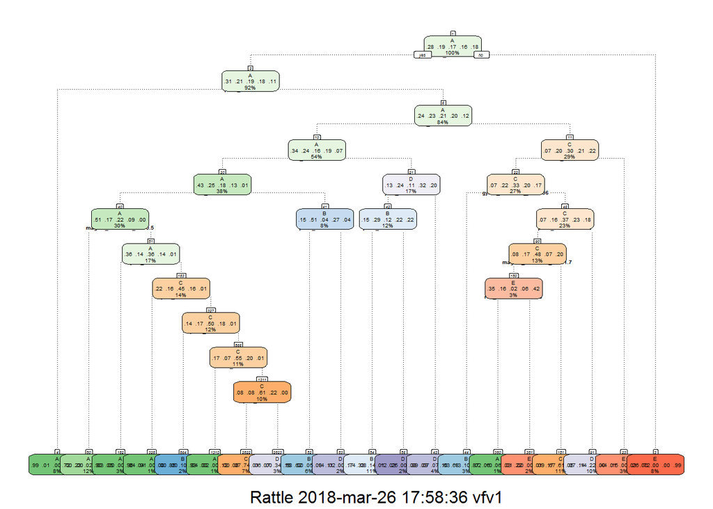

```r
modFitdt<-rpart(classe ~ ., data=training, method="class")
fancyRpartPlot(modFitdt,cex=.3,under.cex=0.2,shadow.offset=0)
```

Now we’ll see the accuracy

```r
predictiondt <- predict(modFitdt, validation, type = "class")

cmtr<-confusionMatrix(validation$classe,predictiondt)
cmtr
```

```
## Confusion Matrix and Statistics
##
##           Reference
## Prediction    A    B    C    D    E
##          A 1139  159   48   46    3
##          B  149  552  130   89   29
##          C   25  107  546  176    1
##          D   32   91   55  574   52
##          E    8  174   63   77  579
##
## Overall Statistics
##
##                Accuracy : 0.6913
##                  95% CI : (0.6781, 0.7042)
##     No Information Rate : 0.2759
##     P-Value [Acc > NIR] : < 2.2e-16
##
##                   Kappa : 0.6101
##  Mcnemar's Test P-Value : < 2.2e-16
##
## Statistics by Class:
##
##                      Class: A Class: B Class: C Class: D Class: E
## Sensitivity            0.8418   0.5097   0.6485   0.5967   0.8720
## Specificity            0.9279   0.8961   0.9239   0.9417   0.9241
## Pos Pred Value         0.8165   0.5817   0.6386   0.7139   0.6426
## Neg Pred Value         0.9390   0.8657   0.9269   0.9054   0.9788
## Prevalence             0.2759   0.2208   0.1717   0.1962   0.1354
## Detection Rate         0.2323   0.1126   0.1113   0.1170   0.1181
## Detection Prevalence   0.2845   0.1935   0.1743   0.1639   0.1837
## Balanced Accuracy      0.8849   0.7029   0.7862   0.7692   0.8980
```

We have an accuracy of 0.69

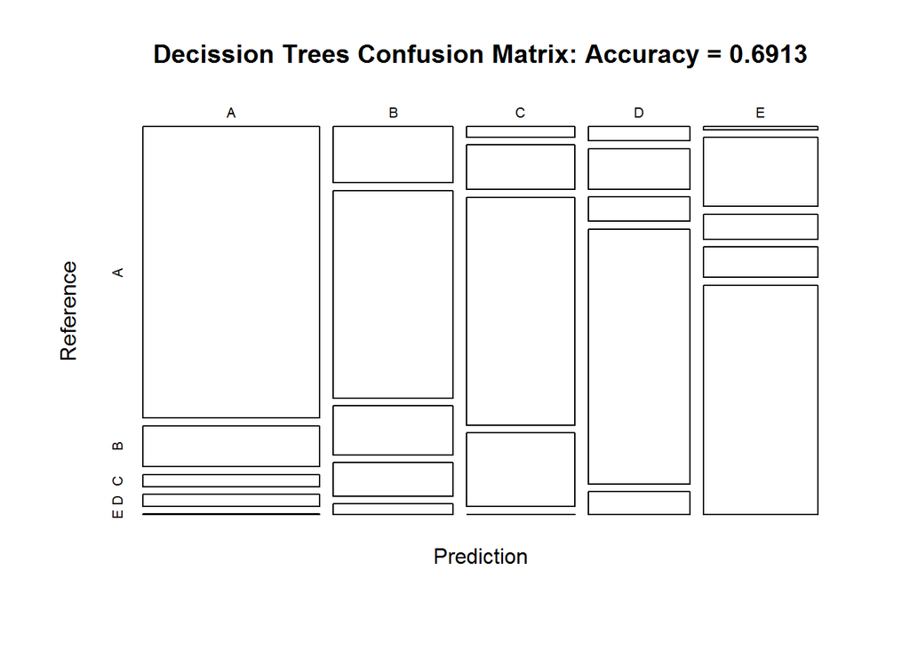

```r
plot(cmtr$table, col = cmtr$byClass, main = paste("Decission Trees Confusion Matrix: Accuracy =", round(cmtr$overall['Accuracy'], 4)))
```

## Random Forest

Then we’ll test the Random Forest for comparisson

```r
set.seed(4444)
modFitrf <- randomForest(classe ~ ., data=training)
predictionrf <- predict(modFitrf, validation, type = "class")
cmrf2 <- confusionMatrix(predictionrf, validation$classe)
cmrf2
```

```
## Confusion Matrix and Statistics
##
##           Reference
## Prediction    A    B    C    D    E
##          A 1392    6    0    0    0
##          B    3  935    3    0    0
##          C    0    6  846    5    0
##          D    0    0    6  799    0
##          E    0    2    0    0  901
##
## Overall Statistics
##
##                Accuracy : 0.9937
##                  95% CI : (0.991, 0.9957)
##     No Information Rate : 0.2845
##     P-Value [Acc > NIR] : < 2.2e-16
##
##                   Kappa : 0.992
##  Mcnemar's Test P-Value : NA
##
## Statistics by Class:
##
##                      Class: A Class: B Class: C Class: D Class: E
## Sensitivity            0.9978   0.9852   0.9895   0.9938   1.0000
## Specificity            0.9983   0.9985   0.9973   0.9985   0.9995
## Pos Pred Value         0.9957   0.9936   0.9872   0.9925   0.9978
## Neg Pred Value         0.9991   0.9965   0.9978   0.9988   1.0000
## Prevalence             0.2845   0.1935   0.1743   0.1639   0.1837
## Detection Rate         0.2838   0.1907   0.1725   0.1629   0.1837
## Detection Prevalence   0.2851   0.1919   0.1748   0.1642   0.1841
## Balanced Accuracy      0.9981   0.9919   0.9934   0.9962   0.9998
```

The random forest model has a 99.4% accuracy, far superior to the rpart method. The specificity and sensitivity is in the high 90s for all variables.

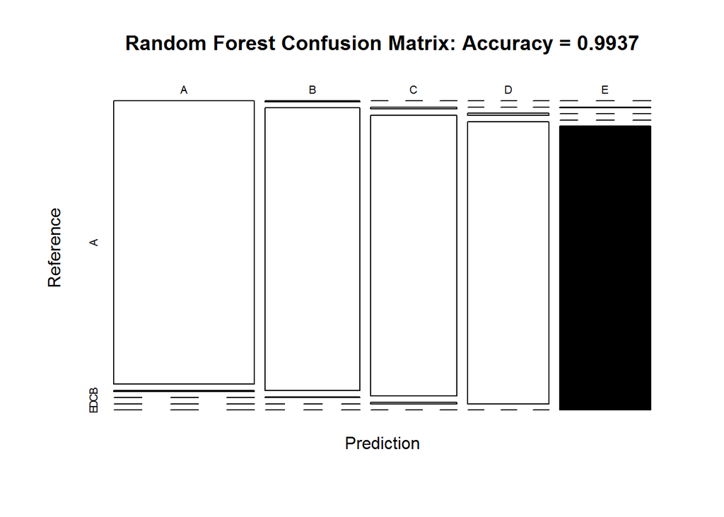

```r
plot(cmrf2$table, col = cmrf2$byClass, main = paste("Random Forest Confusion Matrix: Accuracy =", round(cmrf2$overall['Accuracy'], 4)))
```

## Cross Validation

The cross-validated error for the decision tree is scaled down for easier reading; the error bars on the plot show one standard deviation of the x-validated error.

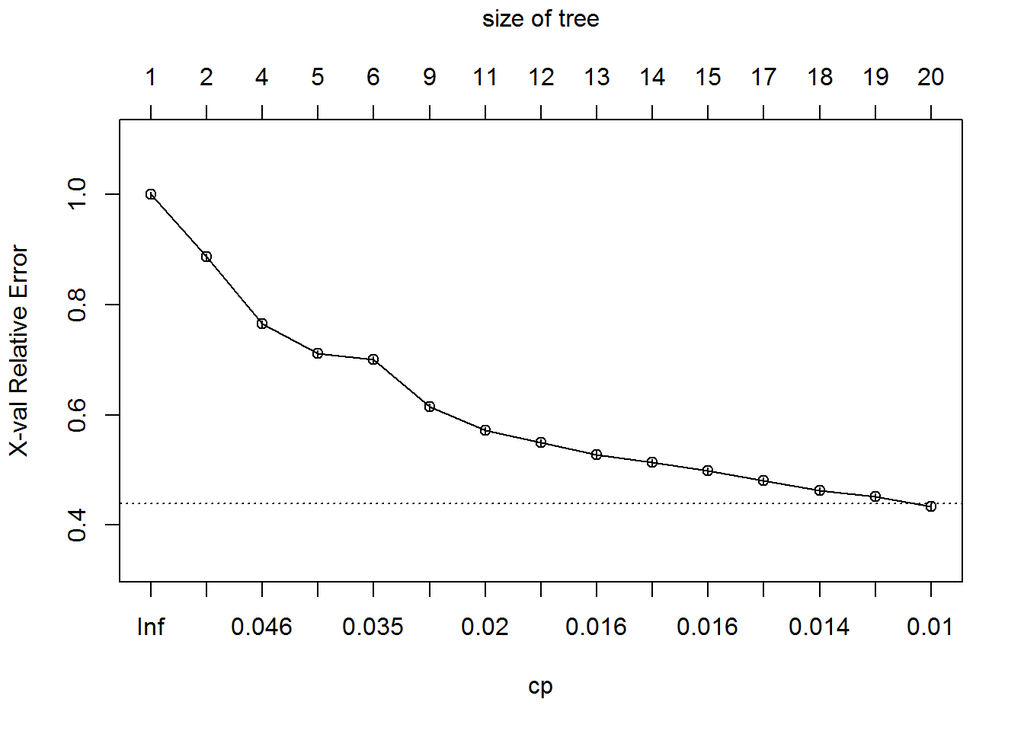

For random forests, there is no need for cross-validation or a separate test set to get an unbiased estimate of the test set error. It is estimated internally , during the run.

## In Sample & Out of Sample Error

```r
insampledt <- predict(modFitdt, training, type = "class")
confusionMatrix(insampledt, training$classe)
```

```
## Confusion Matrix and Statistics
##
##           Reference
## Prediction    A    B    C    D    E
##          A 3411  460   49   80   14
##          B  467 1648  337  344  467
##          C  135  347 1667  169  217
##          D  152  328  514 1687  330
##          E   20   65    0  132 1678
##
## Overall Statistics
##
##                Accuracy : 0.6856
##                  95% CI : (0.6781, 0.6931)
##     No Information Rate : 0.2843
##     P-Value [Acc > NIR] : < 2.2e-16
##
##                   Kappa : 0.6032
##  Mcnemar's Test P-Value : < 2.2e-16
##
## Statistics by Class:
##
##                      Class: A Class: B Class: C Class: D Class: E
## Sensitivity            0.8151   0.5787   0.6494   0.6994   0.6201
## Specificity            0.9428   0.8639   0.9286   0.8924   0.9819
## Pos Pred Value         0.8498   0.5051   0.6576   0.5603   0.8855
## Neg Pred Value         0.9277   0.8952   0.9261   0.9381   0.9198
## Prevalence             0.2843   0.1935   0.1744   0.1639   0.1839
## Detection Rate         0.2318   0.1120   0.1133   0.1146   0.1140
## Detection Prevalence   0.2727   0.2217   0.1722   0.2046   0.1288
## Balanced Accuracy      0.8789   0.7213   0.7890   0.7959   0.8010
```

```r
insamplerf <- predict(modFitrf, training, type = "class")
confusionMatrix(insamplerf, training$classe)
```

```
## Confusion Matrix and Statistics
##
##           Reference
## Prediction    A    B    C    D    E
##          A 4185    0    0    0    0
##          B    0 2848    0    0    0
##          C    0    0 2567    0    0
##          D    0    0    0 2412    0
##          E    0    0    0    0 2706
##
## Overall Statistics
##
##                Accuracy : 1
##                  95% CI : (0.9997, 1)
##     No Information Rate : 0.2843
##     P-Value [Acc > NIR] : < 2.2e-16
##
##                   Kappa : 1
##  Mcnemar's Test P-Value : NA
##
## Statistics by Class:
##
##                      Class: A Class: B Class: C Class: D Class: E
## Sensitivity            1.0000   1.0000   1.0000   1.0000   1.0000
## Specificity            1.0000   1.0000   1.0000   1.0000   1.0000
## Pos Pred Value         1.0000   1.0000   1.0000   1.0000   1.0000
## Neg Pred Value         1.0000   1.0000   1.0000   1.0000   1.0000
## Prevalence             0.2843   0.1935   0.1744   0.1639   0.1839
## Detection Rate         0.2843   0.1935   0.1744   0.1639   0.1839
## Detection Prevalence   0.2843   0.1935   0.1744   0.1639   0.1839
## Balanced Accuracy      1.0000   1.0000   1.0000   1.0000   1.0000
```

## Conclusion

Random Forest was a superior model for prediction of exercise quality compared to rpart decission trees, had over 99% accuracy and fitted well to other subsamples of the data. However, the algorithm may not have as high of accuracy on other samples, particularly ones with different subjects.